# US County Chropleths

You can create a choropleth of US Counties with the function `county_choropleth`:

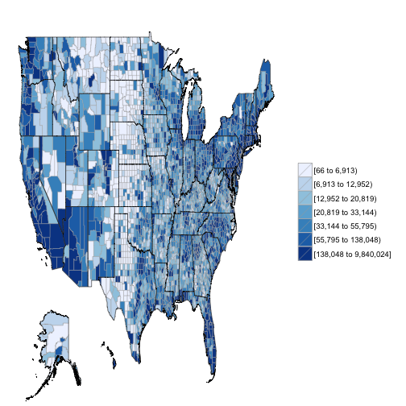

```r
library(choroplethr)

?df_pop_county
data(df_pop_county)

?county_choropleth
county_choropleth(df_pop_county)
```

As demonstrated above, the only required parameter to `county_choropleth` is a data.frame. You can see the optional parameters by typing `?county_choropleth`.

# Data Requirements

The data.frame that you provide to `county_choropleth` must have one column named “region” and one column named “value”. Your entries for “region” must **exactly** match how regions are named in the map which choroplethr uses. These names are defined in the object `county.regions`:

```r
library(choroplethrMaps)

?county.regions
data(county.regions)
head(county.regions)
```

```
##    region county.fips.character county.name state.name
## 1    1001                 01001     autauga    alabama
## 36   1003                 01003     baldwin    alabama
## 55   1005                 01005     barbour    alabama
## 15   1007                 01007        bibb    alabama
## 2    1009                 01009      blount    alabama
## 16   1011                 01011     bullock    alabama
##    state.fips.character state.abb
## 1                    01        AL
## 36                   01        AL
## 55                   01        AL
## 15                   01        AL
## 2                    01        AL
## 16                   01        AL
```

In order to use choroplethr, you must use the naming convention in the “region” column of county.regions. That is, you must use the numeric version of the county FIPS code - i.e. you must drop any leading zeroes.

# Exploring Data

The `county_choropleth` function provides two parameters to facilitate exploring data: `buckets` and `zoom`. buckets defaults to 7, which means that there are 7 colors, and an equal number of counties in each color. Valid values for buckets are integers betwen 1 and 7. If buckets is 1 then a continuous scale will be used. zoom defaults to NULL, which means that all counties are shown. You can set it to be a vector of states. You must name your states as defined in the “region” column of `?state.regions`.

As an example, here is how you can use choroplethr to show the population of US Counties on the West Coast.

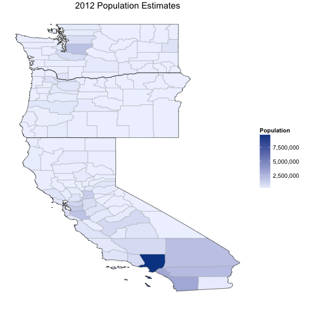

```r
county_choropleth(df_pop_county,
                 title   = "2012 Population Estimates",
                 legend  = "Population",
                 buckets = 1,
                 zoom    = c("california", "washington", "oregon"))
```

If you are interested in zooming in on individual counties, please see the function `?county_zoom_choropleth`.

# Advanced Options

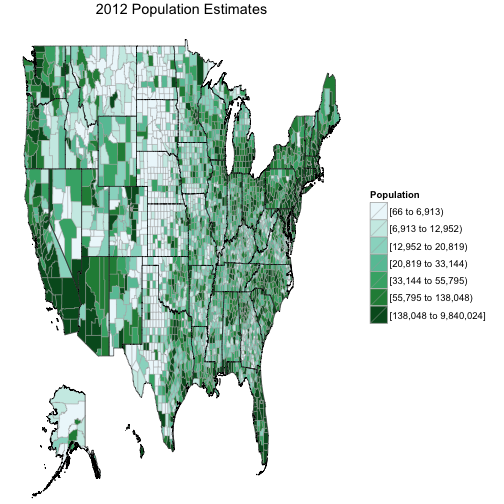

```r
library(ggplot2)

choro = CountyChoropleth$new(df_pop_county)
choro$title = "2012 Population Estimates"
choro$ggplot_scale = scale_fill_brewer(name="Population", palette=2, drop=FALSE)
choro$render()
```

**Note:** Care must be taken when manually setting the scale on `CountyChoropleth` objects. In particular, choroplethr uses ggplot2 custom annotations to render Alaska and Hawaii as insets. This means that the scales of the insets and the main map will only be the same if you do the following

1. for discrete scales, pass `drop=FALSE` to the scale (as above).
2. for continuous scales, pass `limits` which encompass the minimum and maximum values for the entire dataset.